# Collating Keywords

## Aim

In this post we are going explore the possibilities of collating the input parameters and results of function to make summary tables or plots. We are aiming to write a small utility that does this task for us.

## Motivation

We start with a collection of parameters over which the function will be run. It appears that scikit-learn lacks a strightforward way to collate the keyword aruments and the results. One can invoke the cross validating utility, `GrigSearchCV` of scikit-learn, however we are are not interested in validating our result at this stage. Our aim is to obtain a rough boundaries of the sensible parameter space or just generate a grid of results.

The aforementioned module *does* contain an extremely useful functionality [`ParameterGrid`](http://scikit-learn.org/stable/modules/generated/sklearn.model_selection.ParameterGrid.html). This returns an iterator over keyword–value pairs created from the dictionary.

```python
from sklearn.model_selection import ParameterGrid

param_dict = {'param1' : ['a', 'b', 'c'],
              'param2' : [1, 2] }
param_grid = ParameterGrid(param_dict)

for params in param_grid:
    print(params)
```

```
{'param1': 'a', 'param2': 1}
{'param1': 'a', 'param2': 2}
{'param1': 'b', 'param2': 1}
{'param1': 'b', 'param2': 2}
{'param1': 'c', 'param2': 1}
{'param1': 'c', 'param2': 2}
```

We are trying to find ways to collate the results of a function whith its input parameters into a structure similar to the one below, where the third column represents the output from the function:

```
{'param1': 'a', 'param2': 1, 'result' : res1}
{'param1': 'a', 'param2': 2, 'result' : res2}
{'param1': 'b', 'param2': 1, 'result' : res3}
{'param1': 'b', 'param2': 2, 'result' : res4}
{'param1': 'c', 'param2': 1, 'result' : res5}
{'param1': 'c', 'param2': 2, 'result' : res6}
```

## Preliminaries

Firstly, we create a toy function called `calculate_distance` that calculates the $L_{p}$ distance between two real vectors. This function takes a small number of keyword arguments.

- _dist_type_ can be 'eucledian' or 'lp'
- *power* is the order of the norm. It is ignored when dist_type is 'eucledian'
- *scale* is factor to scale the distance with

```python
#---------------------------
def _lp_distance(x1, x2,  power = 1, scale = 1.0):
#---------------------------
  """
  Caclulates the distance between two 1D vectors in Lp sense.
  Parameters:
    x1, x2 (np.ndarray[n_size]) : two vectors of shape (n_size,)
    power (int or float) : power of norm. Default power = 2.
    scale (float) : factor to scale the distance with. Default scale = 2.
  Returns:
    distance (np.float) : the scaled distance between x1 and x2
  """

# --- check input
  if x1.size != x2.size:
    raise ValueError("Unequal length vectors")

  if (x1.ndim != 1) or (x2.ndim != 1):
    raise ValueError("Only 1D vectors are accepted")

  if power < 1:
    raise ValueError("Keyword 'power' must be 1 <. Got: {0}".format(power))

# --- calculate Lp norm
  distance = np.power(np.sum(np.power(np.abs(x1 - x2), power)), 1.0 / power)

# --- scale distance
  distance *= scale

  return distance

#---------------------------
def _eucledian_distance(x1, x2, scale = 1.0):
#---------------------------
  """
  Calculates the Eucledian distance between two vectors
    x1, x2 (np.ndarray[n_size]) : two vectors of shape (n_size,)
    scale (float) : factor to scale the distance with. Default scale = 2.
  Returns:
    distance (np.float) : the scaled Eucledian distance between x1 and x2
  """

  return _lp_distance(x1, x2, power = 2, scale = scale)

#---------------------------
def calculate_distance(x1, x2, dist_type = "eucledian", power = 2, scale = 1.0):
#---------------------------
  """
  Calculates the distance between two 1D vectors
  Parameters:
    x1, x2 (np.ndarray[n_size]) : two vectors of shape (n_size,)
    dist_type (str) : 'eucledian', lp, default = 'eucledian'
    power (int or float) : power of norm. Default power = 2.
    scale (float) : factor to scale the distance with. Default scale = 2.
  Returns:
    distance (np.float) : the scaled distance between x1 and x2
  """

  if dist_type == "eucledian":
    distance = _eucledian_distance(x1, x2, scale = scale)
  elif dist_type == "lp":
    distance = _lp_distance(x1, x2, power = power, scale = scale)
  else:
    raise ValueError("dist_type: must be {0} or {1}. Got: {2}.".format("eucledian", "lp", dist_type))

  return distance
```

It is now all set to write our own utilities to group the keywords and the return values. After initialising the trial vectors:

```python
# set up
import numpy as np

n_size = 10
x1 = np.random.rand(n_size)
x2 = np.random.rand(n_size)
```

### 1. solution: `numpy` structured arrays (slow and dirty)

We are going to store the parameter values and the result in a structured numpy array. The field names are the keyword names and the `res` token for the result.

**Algorithm**

1. Create an empty list `result_grid` to store the parameters and results
2. Loop over the parameters
   1. Evaluate function
   2. Append result to `result_grid`
   3. Create a tuple with the parameter and result values
   4. Append tuple to storage
3. Create a `np.dtype` called `result_grid_type` for the parameters
4. Append the name and the type of the result to `result_grid_type`
5. Cast `result_grid` to a numpy structured array of type `result_grid_type`

```python
# create grig of parameters.
param_dict = {'power' : [1, 2, 10],
              'scale' : [1.0, 2.0]}

param_grid = ParameterGrid(param_dict)
result_grid = []

for params in param_grid:
  res = calculate_distance(x1, x2, **params)

# collate parameters and corresponding result
  result_grid.append((*params.values(), res))

# create a datatype 1. type of parameters
result_grid_type = [(_k, type(_v)) for _k, _v in params.items()]

# append type of result -- we assume it does not change during the iteration.
result_grid_type.append(('res', type(res)))
result_grid = np.array(result_grid, dtype = np.dtype(result_grid_type))
```

The lines

```
result_grid_type = [(_k, type(_v)) for _k, _v in params.items()]
result_grid_type.append(('res', type(res)))
np.dtype(result_grid_type)
```

construct a `numpy dtype` instance, a list of tuples. The first element in each tuple is the field name, the second one is the type of the contained data.

```python
print(np.dtype(result_grid_type))
```

```
[('power', '<i4'), ('scale', '<f8'), ('res', '<f8')]
```

The records are conveniently accessed by their names:

```python
print("power : ", result_grid['power'])
```

```
power :  [ 1  1  2  2 10 10]
```

```python
print("res : ", result_grid['res'])
```

```
res :  [1.47854226 2.95708452 1.47854226 2.95708452 1.47854226 2.95708452]
```

```python
def _set_ptype(pvals):
  """
  Utility to generate numpy compatible string formats.
  If the parameters are a list of string it
  chooses the longest of them as the length in the type descript
  Parameters:
    pvals ([]) : list of parameters
  Returns:
    p_type (type subclass or string) : parameter type
  """
  p_type = type(pvals[0]) # shortcut at first element

  if p_type is not str:
    return p_type

  max_string_len = max(list(map(lambda x : len(x), pvals)))
  p_type = 'U'+str(max_string_len)

  return p_type
```

### 2. solution: `defaultdict` and `pandas dataframe` (quick and dirty)

A considerably more convenient solution is to use `defaultdict`s and a Pandas `dataframe` to collate the results. Pandas will take care of setting the types. The `result_dict` is a `defaultdict` whose default values are lists. The keys are the keywords for the parameters and the `res` token for the results.

**Algorithm**

1. Initialise an empty dictionary of lists `result_dict` to store parameters and results
2. Loop over parameters
   1. Evaluate function
   2. Append the parameter values to the correspnding lists
   3. Append the result value to the `res` list
3. Convert `result_dict` to pandas dataframe

```python
from collections import defaultdict
import pandas as pd

result_dict = defaultdict(list)

for params in param_grid:
  res = calculate_distance(x1, x2, **params)
  [result_dict[_k].append(_v) for _k, _v in params.items()]
  result_dict['res'].append(res)

result_df = pd.DataFrame.from_dict(result_dict)
```

```python
result_df
```

|  | power | res | scale |
| --- | --- | --- | --- |
| 0 | 1 | 1.478542 | 1.0 |
| 1 | 1 | 2.957085 | 2.0 |
| 2 | 2 | 1.478542 | 1.0 |
| 3 | 2 | 2.957085 | 2.0 |
| 4 | 10 | 1.478542 | 1.0 |
| 5 | 10 | 2.957085 | 2.0 |

### 3. solution: dictionary and pandas (quick, with better hygiene standards)

There might be some cases when some of the keywords become meaningless *e.g.* passing `power = n` when calculating the Eucledian norm with the `dist_type = 'euclidian'` option. In order to avoid surplus runs, `ParameterGrid` allows us to create a list of dictionaries.

```python
param_dict = [{'dist_type' : ['eucledian'],
               'scale' : [1.0, 2.0]},
              {'dist_type' : ['lp'],
               'power' : [1, 3],
               'scale' : [1.0, 2.0]}]

param_grid = ParameterGrid(param_dict)

for params in param_grid:
    print(params)
```

```
{'dist_type': 'eucledian', 'scale': 1.0}
{'dist_type': 'eucledian', 'scale': 2.0}
{'dist_type': 'lp', 'power': 1, 'scale': 1.0}
{'dist_type': 'lp', 'power': 1, 'scale': 2.0}
{'dist_type': 'lp', 'power': 3, 'scale': 1.0}
{'dist_type': 'lp', 'power': 3, 'scale': 2.0}
```

As a consequence, we are going to collect the parameters and the result in a list of dictionaries and convert that to a pandas dataframe.

**Algorithm**

1. Create empty list for storage `result_list`
2. Loop over parameters
   1. Evaluate function
   2. Create a dictionary, `_res_dict` of parameters
   3. Update dictionary with the result
   4. Append to storage, `result_list`
3. Convert `result_list` to `pandas dataframe`

```python
result_list = [] # storage for parameters and results for all runs

for params in param_grid:
  res = calculate_distance(x1, x2, **params)

  _res_dict = dict(**params)           # store parameters. Do not contaminate params dict
  _res_dict.update({'res' : res})      # append result to dictionary
  result_list.append(_res_dict)

result_df = pd.DataFrame(result_list)
```

```python
result_df
```

|  | dist_type | power | res | scale |
| --- | --- | --- | --- | --- |
| 0 | eucledian | NaN | 1.478542 | 1.0 |
| 1 | eucledian | NaN | 2.957085 | 2.0 |
| 2 | lp | 1.0 | 4.024630 | 1.0 |
| 3 | lp | 1.0 | 8.049260 | 2.0 |
| 4 | lp | 3.0 | 1.089952 | 1.0 |
| 5 | lp | 3.0 | 2.179904 | 2.0 |

We can see that the `power` parameter is replaced with `NaN`-s, where it is not used. They can easily be tidied up with calling

`result_df['power'].fillna(0, inplace = True)`

The apt reader have surely recognsised that Solutions 1. and 2. were subclasses of the one discussed here.

### 4. solution: `get_params`, dictionary and `pandas dataframe` (quick, remarkable personal hygiene)

The `scikit-learn` estimators, classifiers *etc.* usually have a built in `get_params()` method that retrieves all of the parameters. This can be used in conjuction with the method above. In the following example we try to estimate down the minimum required number of runs and iterations to minimse stress in multidimensional scaling. (*N.B.* obviously, one might wish to cross-validate these results.)

**Algorithm**

1. Create empty list for storage `result_list`
2. Loop over parameters
   1. Evaluate function
   2. Create a dictionary, `_res_dict` of parameters
   3. Retrieve the estimator's parameters with `get_params()`
   4. Update dictionary with the result
   5. Append to storage, `result_list`
3. Convert `result_list` to `pandas dataframe`

```python
from sklearn.manifold import MDS

# generate a 10D random data set
n_samples, n_features = 100, 10
X = np.random.rand(n_samples, n_features)

# number of SMACOF cycles and restarts
param_dict = { 'max_iter' : [10, 100, 300, 500],
              'n_init' : [1, 2, 5, 10]}

param_grid = ParameterGrid(param_dict)

# instantantiate transformer
mds = MDS()

# explore parameter space
result_list = []

for params in param_grid:
    mds.set_params(**params)
    mds.fit_transform(X)

    _res_dict = mds.get_params()
    _res_dict.update({'stress' : mds.stress_})
    result_list.append(_res_dict)

result_df = pd.DataFrame(result_list)
```

The resultant dataframe looks like:

```python
result_df.head()
```

|  | dissimilarity | eps | max_iter | metric | n_components | n_init | n_jobs | random_state | stress | verbose |
| --- | --- | --- | --- | --- | --- | --- | --- | --- | --- | --- |
| 0 | euclidean | 0.001 | 10 | True | 2 | 1 | 1 | None | 1520.536961 | 0 |
| 1 | euclidean | 0.001 | 10 | True | 2 | 2 | 1 | None | 1476.601978 | 0 |
| 2 | euclidean | 0.001 | 10 | True | 2 | 5 | 1 | None | 1389.753876 | 0 |
| 3 | euclidean | 0.001 | 10 | True | 2 | 10 | 1 | None | 1424.071023 | 0 |
| 4 | euclidean | 0.001 | 100 | True | 2 | 1 | 1 | None | 1202.992006 | 0 |

We can now visually inspect which are the optimal parameters.

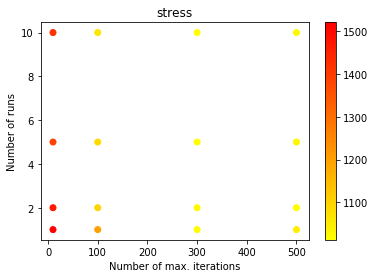

```python
from matplotlib import pyplot as plt

cmap = plt.get_cmap('hot_r')
plt.title('stress')
plt.xlabel('Number of max. iterations')
plt.ylabel('Number of runs')
plt.scatter(result_df['max_iter'], result_df['n_init'],
            cmap = plt.get_cmap('autumn_r'), c = result_df['stress'])
plt.colorbar()
plt.show()
```

### Summary

In this post we have designed a couple of generic framworks to collate keyword parameters of a function and its result. They based on grouping the parameters and results in an intermediary data objects, such as list of dictionaries, then injecting these group to a single keyable data structure